# Genes regulados por p53-SET

Ulises Gaspar

Se importan librerías:

```r
library(limma)
library(edgeR)
library("pheatmap")
library(ggplot2)
library(gplots)
```

Se cargan los datos de fc:

```r
setwd("/Users/hecto/Downloads")
fc <- read.table("counts.txt", header = T)
```

Cargar información a edgeR:

```r
samples <- factor(c("WildType", "WildType", "WildTypeKnockDown", "WildTypeKnockDown", "p53KnockOut", "p53KnockOut", "p53KnockOutKnockDown", "p53KnockOutKnockDown"))

DGEList_p53 = DGEList(counts=fc[,3:10], group=samples, genes=fc[,1:2])
dim(DGEList_p53)
```

```
## [1] 55385     8
```

Se eliminan genes con baja expresión

```r
keep = rowSums(cpm(DGEList_p53)>1) >= 3
DGEList_p53 = DGEList_p53[keep,]
dim(DGEList_p53)
```

```
## [1] 8476    8
```

Se genera la matriz de diseño

```r
design <- model.matrix(~0+samples)
colnames(design) <- levels(samples)
```

Factores de normalización y variación de las muestras:

```r
DGEList_p53 = calcNormFactors(DGEList_p53)
DGEList_p53 = estimateDisp(DGEList_p53, design = design)
```

Se genera un PCA. Se consideran aquellos con p53 funcional como control (solo las primeras dos muestras)

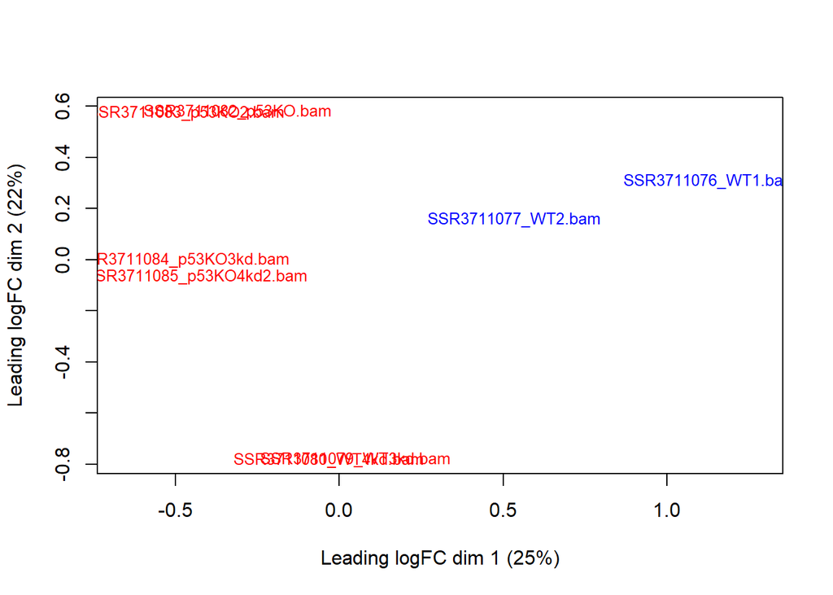

```r
colors = c("blue", "blue", "red", "red", "red", "red", "red", "red")
plotMDS(DGEList_p53, cex = 0.8, col = colors, )
```

Se observa como los datos se agrupan en su grupo correspondiente.

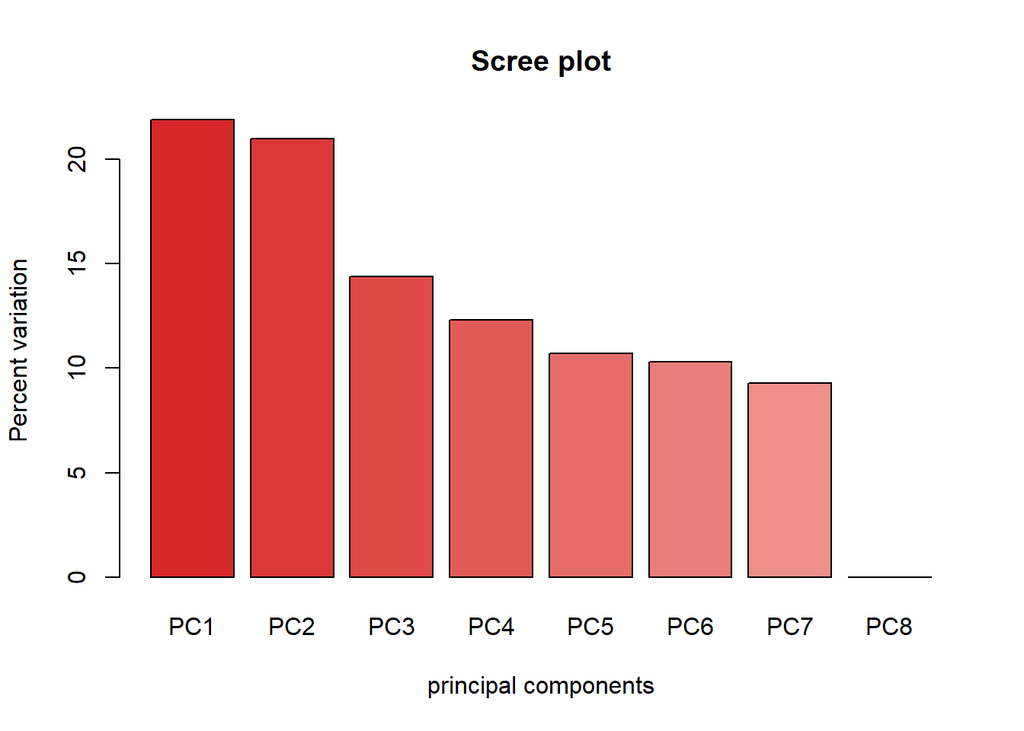

```r
PCA_log2CPM = prcomp(t(cpm(DGEList_p53, log = T)), center = T, scale = T)
PCA_perc_var = round(((PCA_log2CPM$sdev^2/sum(PCA_log2CPM$sdev^2))*100), 1)

color_range <- colorRampPalette(c("#d62828", "#FED4CC"))

barplot(PCA_perc_var, names = colnames(PCA_log2CPM$x), main = "Scree plot", col = color_range(11), xlab = "principal components", ylab = "Percent variation")
```

Los 2 primeros componentes parecen explicar mucha de la variabilidad (~20% cada uno), pero aún así no es tan fuerte.

Se procede a calcular los genes expresados diferencialmente Como tenemos 4 grupos, y solo 1 tiene p53 funcional, consideré que solo 2 conrastes son necesarios, replicando el paper: CRISPR Ctr (Wt) vs CRISPR Crt/SET kd, y CRISPR Ctr/SET kd vs CRISPR p55 KO/SET kd

```r
fit <- glmFit(DGEList_p53, design)

#contrastWTSETkd_v_WT <- glmLRT(fit, contrast = makeContrasts(WildTypeKnockDown - WildType, levels = design))
contrastWT_v_WTSETkd <- glmLRT(fit, contrast = makeContrasts(WildType - WildTypeKnockDown, levels = design))

#contrastWTSETkd_v_p53KOSETkd <- glmLRT(fit, contrast = makeContrasts(WildTypeKnockDown - p53KnockOutKnockDown, levels = design))
contrastp53KOSETkd_v_WTSETkd <- glmLRT(fit, contrast = makeContrasts(p53KnockOutKnockDown - WildTypeKnockDown, levels = design))
```

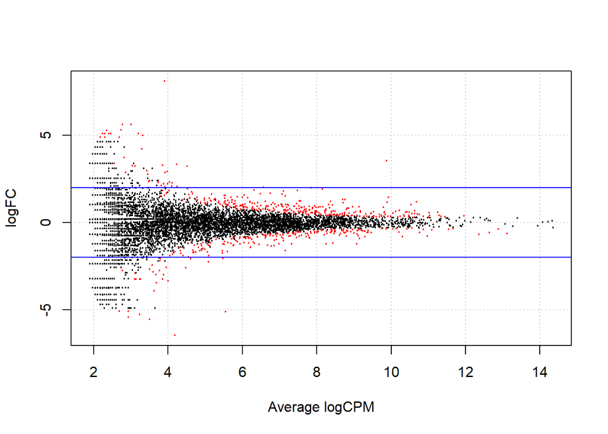

```r
dt_significant1 <- decideTestsDGE(contrastWT_v_WTSETkd, adjust.method = "BH", p.value = 0.05)
vctr_names_sig1 <- rownames(DGEList_p53)[as.logical(dt_significant1)]
plotSmear(contrastWT_v_WTSETkd, de.tags = vctr_names_sig1)
abline(h = c(-2,2), col = "blue")
```

Se visualizan los genes del contraste entre CRISPR Ctr/SETkd vs CRISPR p55 KO/SET kd:

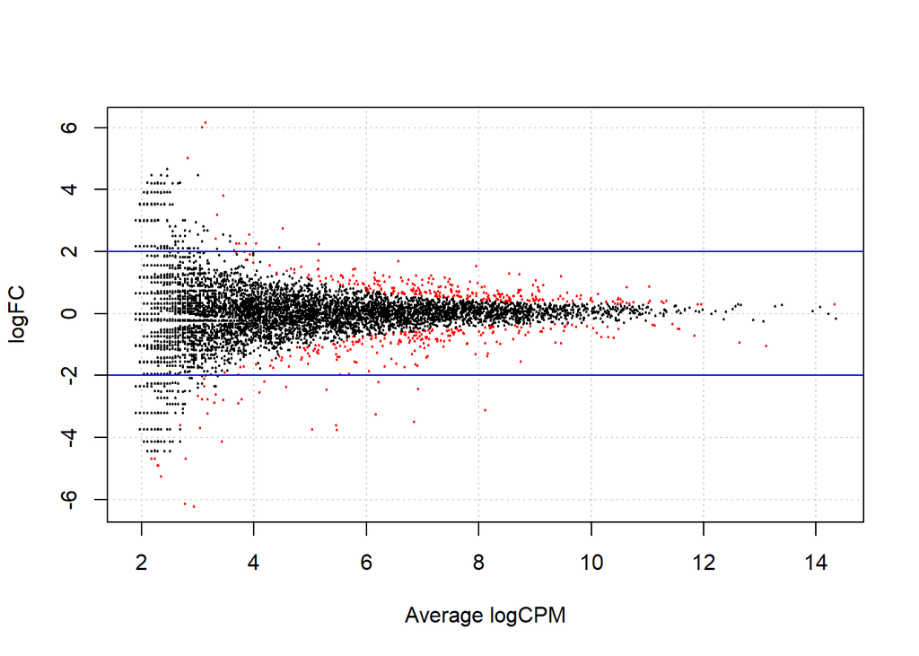

```r
dt_significant2 <- decideTestsDGE(contrastp53KOSETkd_v_WTSETkd, adjust.method = "BH", p.value = 0.05)
vctr_names_sig2 <- rownames(DGEList_p53)[as.logical(dt_significant2)]
plotSmear(contrastp53KOSETkd_v_WTSETkd, de.tags = vctr_names_sig2)
abline(h = c(-2,2), col = "blue")
```

Heatmap herárquico de genes expresados diferencialmente:

```r
vctr_sig <- as.logical(decideTestsDGE(contrastWT_v_WTSETkd, adjust.method = "BH", p.value = 0.000005))
vctr_sig<- vctr_sig | as.logical(decideTestsDGE(contrastp53KOSETkd_v_WTSETkd, adjust.method = "BH", p.value = 0.000005))
vctr_names_hcl <- rownames(DGEList_p53)[vctr_sig]
length(vctr_names_hcl)
```

```
## [1] 133
```

```r
mtrx_significant <- DGEList_p53$counts[vctr_names_hcl, ]

Genes_significant <- DGEList_p53$genes[vctr_names_hcl, ]

vctr_colors =  as.factor(c("black", "red", "green", "blue"))
```

```r
vctr_sample_colors <- as.character(vctr_colors[as.numeric(DGEList_p53$samples$group)])
vctr_sample_colors
```

```
## [1] "green" "green" "blue"  "blue"  "black" "black" "red"   "red"
```

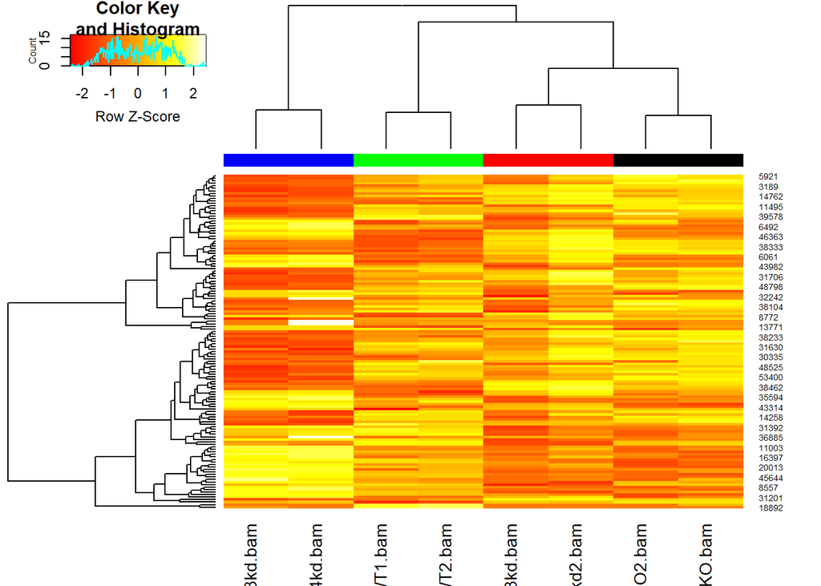

```r
heatmap.2(log2(mtrx_significant + 1), ColSideColors = vctr_sample_colors, key = TRUE, trace = "none", col = heat.colors(200), scale = "row")
```

Se procede a hacer el análisis de ontología de genes:

```r
if (!require("BiocManager", quietly = TRUE))
    install.packages("BiocManager")
BiocManager::install("clusterProfiler")
if (!require("BiocManager", quietly = TRUE))
    install.packages("BiocManager")

BiocManager::install("AnnotationDbi")
if (!require("BiocManager", quietly = TRUE))
    install.packages("BiocManager")

BiocManager::install("org.Mm.eg.db")
library(clusterProfiler)
library(org.Mm.eg.db)
library(AnnotationDbi)
```

Proceso biológico

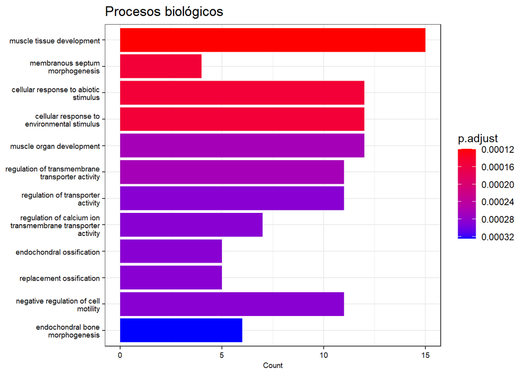

```r
GO_results = enrichGO(gene = Genes_significant$GeneID, OrgDb = org.Mm.eg.db, keyType = "ENSEMBL", ont = "BP")
plot(barplot(GO_results, showCategory = 12, font.size = 7, title = "Procesos biológicos"))
```

Función molecular:

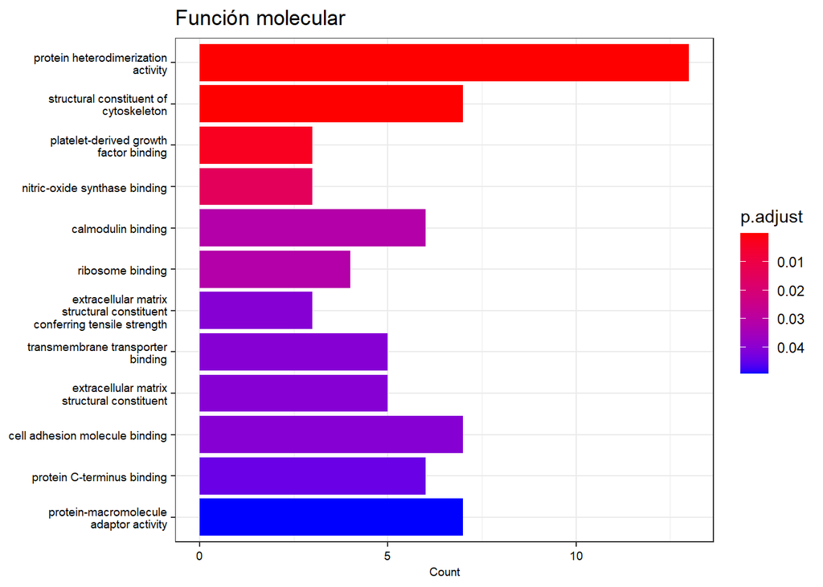

```r
GO_resultsMF = enrichGO(gene = Genes_significant$GeneID, OrgDb = org.Mm.eg.db, keyType = "ENSEMBL", ont = "MF")
plot(barplot(GO_resultsMF, showCategory = 12, font.size = 7, title = "Función molecular"))
```

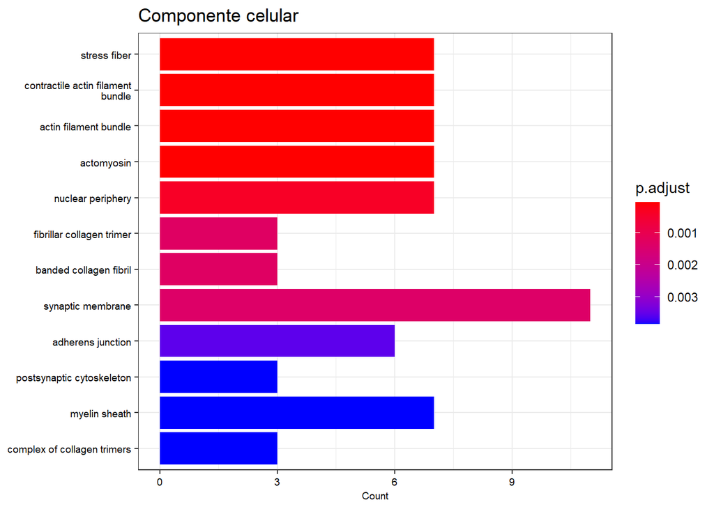

```r
GO_resultsCC = enrichGO(gene = Genes_significant$GeneID, OrgDb = org.Mm.eg.db, keyType = "ENSEMBL", ont = "CC")
plot(barplot(GO_resultsCC, showCategory = 12, font.size = 7, title = "Componente celular"))
```